# MW-HR-SIP

Nick Youngblut

2016-08-15

# Introduction

## HR-SIP method workflow:

- Remove sparsely occuring OTUs under the assumption that they are sequencing errors.
  - This is assuming that an OTU should at least be seen in a set number of fractions from the same gradient, since it’s DNA should be (approximately) normally distributed.
- For each OTU, use DESeq2 to detect significant enrichment of in ‘heavy’ gradient fractions.
  - ‘heavy’ gradients are selected *ad hoc*
  - Multiple hypotheses are adjusted for.
  - Significantly enriched OTUs are considered to have incorporated isotope (incorporators)

## MW-HR-SIP method workflow:

- The method is similar to HR-SIP, except instead of 1 ‘heavy’ BD window used, multiple windows are used, but the tradeoff is the higher number of multiple hypotheses that must be corrected for.
  - For each OTU, the BD window with highest log2 fold change (l2fc) value is used, so the BD window can vary among OTUs.
- This method has been shown to be generally more sensitive (more true positives) than HR-SIP and more specific (less false positives) than q-SIP. See the manuscript “Multiple window High Resolution Stable Isotope Probing (MW-HR-SIP)” for more information.

# Dataset

First, let’s load some packages including `HTSSIP`.

```r
library(dplyr)
library(ggplot2)
library(HTSSIP)
```

## Dataset

See HTSSIP introduction vignette for a description on why dataset parsing (all treatment-control comparisons) is needed.

Let’s see the already parsed dataset

```r
physeq_S2D2_l
```

```
## $`(Substrate=='12C-Con' & Day=='3') | (Substrate=='13C-Cel' & Day == '3')`
## phyloseq-class experiment-level object
## otu_table()   OTU Table:         [ 10001 taxa and 46 samples ]
## sample_data() Sample Data:       [ 46 samples by 17 sample variables ]
## tax_table()   Taxonomy Table:    [ 10001 taxa by 8 taxonomic ranks ]
## phy_tree()    Phylogenetic Tree: [ 10001 tips and 10000 internal nodes ]
##
## $`(Substrate=='12C-Con' & Day=='14') | (Substrate=='13C-Cel' & Day == '14')`
## phyloseq-class experiment-level object
## otu_table()   OTU Table:         [ 10001 taxa and 46 samples ]
## sample_data() Sample Data:       [ 46 samples by 17 sample variables ]
## tax_table()   Taxonomy Table:    [ 10001 taxa by 8 taxonomic ranks ]
## phy_tree()    Phylogenetic Tree: [ 10001 tips and 10000 internal nodes ]
##
## $`(Substrate=='12C-Con' & Day=='14') | (Substrate=='13C-Glu' & Day == '14')`
## phyloseq-class experiment-level object
## otu_table()   OTU Table:         [ 10001 taxa and 47 samples ]
## sample_data() Sample Data:       [ 47 samples by 17 sample variables ]
## tax_table()   Taxonomy Table:    [ 10001 taxa by 8 taxonomic ranks ]
## phy_tree()    Phylogenetic Tree: [ 10001 tips and 10000 internal nodes ]
##
## $`(Substrate=='12C-Con' & Day=='3') | (Substrate=='13C-Glu' & Day == '3')`
## phyloseq-class experiment-level object
## otu_table()   OTU Table:         [ 10001 taxa and 46 samples ]
## sample_data() Sample Data:       [ 46 samples by 17 sample variables ]
## tax_table()   Taxonomy Table:    [ 10001 taxa by 8 taxonomic ranks ]
## phy_tree()    Phylogenetic Tree: [ 10001 tips and 10000 internal nodes ]
```

# HR-SIP

Let’s set some parameters used later.

```r
# adjusted P-value cutoff
padj_cutoff = 0.1
# number of cores for parallel processing
ncores = 8
```

## One treatment-control comparison

First, we’ll just run HR-SIP on 1 treatment-control comparison. Let’s get the individual phyloseq object.

```r
physeq = physeq_S2D2_l[[1]]
physeq
```

```
## phyloseq-class experiment-level object
## otu_table()   OTU Table:         [ 10001 taxa and 46 samples ]
## sample_data() Sample Data:       [ 46 samples by 17 sample variables ]
## tax_table()   Taxonomy Table:    [ 10001 taxa by 8 taxonomic ranks ]
## phy_tree()    Phylogenetic Tree: [ 10001 tips and 10000 internal nodes ]
```

Let’s check that the samples belong to either a 13C-treatment or 12C-control.

```r
physeq %>% sample_data %>% .$Substrate %>% table
```

```
## .
## 12C-Con 13C-Cel
##      23      23
```

OK, we should be ready to run HR-SIP!

Note that the `design` parameter for `HRSIP()` is the experimental design parameter for calculating log2 fold change (l2fc) values with DESeq. Here, it’s used to distinguish label-treatment and unlabel-control samples.

```r
df_l2fc = HRSIP(physeq,
                design = ~Substrate,
                padj_cutoff = padj_cutoff)
```

```
## Sparsity threshold: 0
## Density window: 1.7-1.75
## Sparsity threshold: 0.1
## Density window: 1.7-1.75
## Sparsity threshold: 0.2
## Density window: 1.7-1.75
## Sparsity threshold: 0.3
## Density window: 1.7-1.75
## Sparsity threshold with the most rejected hypotheses: 0.3
```

```r
df_l2fc %>% head(n=3)
```

```
## # A tibble: 3 x 17
##        OTU log2FoldChange         p  padj    Rank1            Rank2
##      <chr>          <dbl>     <dbl> <dbl>   <fctr>           <fctr>
## 1  OTU.514     -0.2504081 0.8504578     1 Bacteria __Proteobacteria
## 2  OTU.816     -0.5615771 0.9137773     1 Bacteria __Proteobacteria
## 3 OTU.1099     -0.2104345 0.7761086     1 Bacteria  __Acidobacteria
## # ... with 11 more variables: Rank3 <fctr>, Rank4 <fctr>, Rank5 <fctr>,
## #   Rank6 <fctr>, Rank7 <fctr>, Rank8 <fctr>, density_min <dbl>,
## #   density_max <dbl>, sparsity_threshold <dbl>, sparsity_apply <chr>,
## #   l2fc_threshold <dbl>
```

How many “incorporators”" (rejected hypotheses)?

```r
df_l2fc %>%
  filter(padj < padj_cutoff) %>%
  group_by() %>%
  summarize(n_incorp_OTUs = OTU %>% unique %>% length)
```

```
## # A tibble: 1 x 1
##   n_incorp_OTUs
##           <int>
## 1             8
```

Let’s plot a breakdown of incorporators for each phylum.

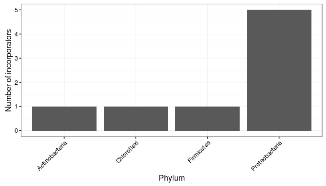

```r
# summarizing
df_l2fc_s = df_l2fc %>%
  filter(padj < padj_cutoff) %>%
  mutate(Rank2 = gsub('^__', '', Rank2)) %>%
  group_by(Rank2) %>%
  summarize(n_incorp_OTUs = OTU %>% unique %>% length) %>%
  ungroup()

# plotting
ggplot(df_l2fc_s, aes(Rank2, n_incorp_OTUs)) +
    geom_bar(stat='identity') +
    labs(x='Phylum', y='Number of incorporators') +
    theme_bw() +
    theme(
      axis.text.x = element_text(angle=45, hjust=1)
    )
```

## All treatment-control comparisons

Let’s now run HR-SIP on all treatment-control comparisons in the dataset:

```r
# Number of comparisons
physeq_S2D2_l %>% length
```

```
## [1] 4
```

The function `plyr::ldply()` is useful (compared to `lapply()`) beccause it can be run in parallel and returns a data.frame object.

```r
# Running in parallel; you may need to change the backend for your environment.
# Or you can just set .parallel=FALSE.
doParallel::registerDoParallel(ncores)

df_l2fc = plyr::ldply(physeq_S2D2_l,
                      HRSIP,
                      design = ~Substrate,
                      padj_cutoff = padj_cutoff,
                      .parallel=TRUE)
df_l2fc %>% head(n=3)
```

```
##                                                                       .id
## 1 (Substrate=='12C-Con' & Day=='3') | (Substrate=='13C-Cel' & Day == '3')
## 2 (Substrate=='12C-Con' & Day=='3') | (Substrate=='13C-Cel' & Day == '3')
## 3 (Substrate=='12C-Con' & Day=='3') | (Substrate=='13C-Cel' & Day == '3')
##        OTU log2FoldChange         p padj    Rank1            Rank2
## 1  OTU.514     -0.2504081 0.8504578    1 Bacteria __Proteobacteria
## 2  OTU.816     -0.5615771 0.9137773    1 Bacteria __Proteobacteria
## 3 OTU.1099     -0.2104345 0.7761086    1 Bacteria  __Acidobacteria
##                   Rank3                  Rank4            Rank5
## 1 __Deltaproteobacteria    __Desulfobacterales __Nitrospinaceae
## 2 __Deltaproteobacteria    __Desulfobacterales __Nitrospinaceae
## 3               __32-21 __uncultured_bacterium             <NA>
##          Rank6                  Rank7 Rank8 density_min density_max
## 1 __uncultured __uncultured_bacterium  <NA>         1.7        1.75
## 2 __uncultured __uncultured_bacterium  <NA>         1.7        1.75
## 3         <NA>                   <NA>  <NA>         1.7        1.75
##   sparsity_threshold sparsity_apply l2fc_threshold
## 1                0.3            all           0.25
## 2                0.3            all           0.25
## 3                0.3            all           0.25
```

Each specific phyloseq subset (treatment-control comparison) is delimited with the “.id” column.

```r
df_l2fc %>% .$.id %>% unique
```

```
## [1] "(Substrate=='12C-Con' & Day=='3') | (Substrate=='13C-Cel' & Day == '3')"
## [2] "(Substrate=='12C-Con' & Day=='14') | (Substrate=='13C-Cel' & Day == '14')"
## [3] "(Substrate=='12C-Con' & Day=='14') | (Substrate=='13C-Glu' & Day == '14')"
## [4] "(Substrate=='12C-Con' & Day=='3') | (Substrate=='13C-Glu' & Day == '3')"
```

For clarity, I’m going edit these long strings to make them more readable when plotted.

```r
df_l2fc = df_l2fc %>%
  mutate(.id = gsub(' \\| ', '\n', .id))
df_l2fc %>% .$.id %>% unique
```

```
## [1] "(Substrate=='12C-Con' & Day=='3')\n(Substrate=='13C-Cel' & Day == '3')"
## [2] "(Substrate=='12C-Con' & Day=='14')\n(Substrate=='13C-Cel' & Day == '14')"
## [3] "(Substrate=='12C-Con' & Day=='14')\n(Substrate=='13C-Glu' & Day == '14')"
## [4] "(Substrate=='12C-Con' & Day=='3')\n(Substrate=='13C-Glu' & Day == '3')"
```

How many incorporators (rejected hypotheses) & which sparsity cutoff was used for each comparison?

Note: you could set one sparsity cutoff for all comparisons by setting the `sparsity_cutoff` to a specific value.

```r
df_l2fc %>%
  filter(padj < padj_cutoff) %>%
  group_by(.id, sparsity_threshold) %>%
  summarize(n_incorp_OTUs = OTU %>% unique %>% length) %>%
  as.data.frame
```

```
##                                                                        .id
## 1 (Substrate=='12C-Con' & Day=='14')\n(Substrate=='13C-Cel' & Day == '14')
## 2 (Substrate=='12C-Con' & Day=='14')\n(Substrate=='13C-Glu' & Day == '14')
## 3   (Substrate=='12C-Con' & Day=='3')\n(Substrate=='13C-Cel' & Day == '3')
## 4   (Substrate=='12C-Con' & Day=='3')\n(Substrate=='13C-Glu' & Day == '3')
##   sparsity_threshold n_incorp_OTUs
## 1                0.2           158
## 2                0.3           234
## 3                0.3             8
## 4                0.3            50
```

How about a breakdown of incorporators for each phylum in each comparision.

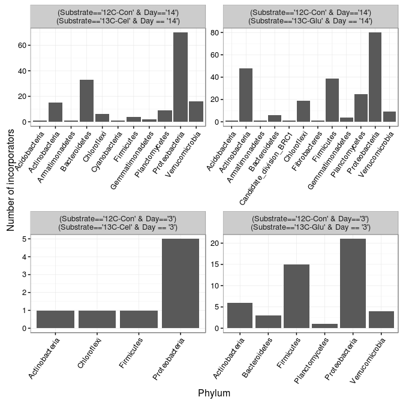

```r
# summarizing
df_l2fc_s = df_l2fc %>%
  filter(padj < padj_cutoff) %>%
  mutate(Rank2 = gsub('^__', '', Rank2)) %>%
  group_by(.id, Rank2) %>%
  summarize(n_incorp_OTUs = OTU %>% unique %>% length) %>%
  ungroup()

# plotting
ggplot(df_l2fc_s, aes(Rank2, n_incorp_OTUs)) +
    geom_bar(stat='identity') +
    labs(x='Phylum', y='Number of incorporators') +
    facet_wrap(~ .id, scales='free') +
    theme_bw() +
    theme(
      axis.text.x = element_text(angle=55, hjust=1)
    )
```

# MW-HR-SIP

MW-HR-SIP is run very similarly to HRSIP, but it uses multiple buoyant density (BD) windows. MW-HR-SIP is performed with the `HRSIP()` function, but multiple BD windows are specified.

Let’s use 3 buoyant density windows (g/ml^-1):

> 1.70-1.73, 1.72-1.75, 1.74-1.77

```r
windows = data.frame(density_min=c(1.70, 1.72, 1.74),
                     density_max=c(1.73, 1.75, 1.77))
windows
```

```
##   density_min density_max
## 1        1.70        1.73
## 2        1.72        1.75
## 3        1.74        1.77
```

Running HRSIP with all 3 BD windows. Let’s run this in parallel to speed things up.

You can turn off parallel processing by setting the `parallel` option to `FALSE`. Also, there’s 2 different levels that could be parallelized: either the `ldply()` or `HRSIP()`. Here, I’m running HRSIP in parallel, but it may make sence in other situations (eg., many comparisons but few density windows and/or sparsity cutoffs).

```r
doParallel::registerDoParallel(ncores)

df_l2fc = plyr::ldply(physeq_S2D2_l,
                      HRSIP,
                      density_windows=windows,
                      design = ~Substrate,
                      padj_cutoff = padj_cutoff,
                      parallel=TRUE)
```

```
## Sparsity threshold with the most rejected hypotheses: 0.3
## Sparsity threshold with the most rejected hypotheses: 0.2
## Sparsity threshold with the most rejected hypotheses: 0.3
## Sparsity threshold with the most rejected hypotheses: 0.3
```

```r
df_l2fc %>% head(n=3)
```

```
##                                                                       .id
## 1 (Substrate=='12C-Con' & Day=='3') | (Substrate=='13C-Cel' & Day == '3')
## 2 (Substrate=='12C-Con' & Day=='3') | (Substrate=='13C-Cel' & Day == '3')
## 3 (Substrate=='12C-Con' & Day=='3') | (Substrate=='13C-Cel' & Day == '3')
##        OTU log2FoldChange         p      padj    Rank1            Rank2
## 1  OTU.514     -0.1952960 0.7648157 1.0000000 Bacteria __Proteobacteria
## 2 OTU.1136      1.5682247 0.0199097 0.8410301 Bacteria  __Acidobacteria
## 3 OTU.2119      0.4825207 0.3663796 1.0000000 Bacteria  __Acidobacteria
##                   Rank3                  Rank4            Rank5
## 1 __Deltaproteobacteria    __Desulfobacterales __Nitrospinaceae
## 2               __DA023 __uncultured_bacterium             <NA>
## 3               __DA023                   <NA>             <NA>
##          Rank6                  Rank7 Rank8 density_min density_max
## 1 __uncultured __uncultured_bacterium  <NA>         1.7        1.73
## 2         <NA>                   <NA>  <NA>         1.7        1.73
## 3         <NA>                   <NA>  <NA>         1.7        1.73
##   sparsity_threshold sparsity_apply l2fc_threshold
## 1                0.3            all           0.25
## 2                0.3            all           0.25
## 3                0.3            all           0.25
```

Let’s check that we have all treatment-control comparisons.

```r
df_l2fc %>% .$.id %>% unique
```

```
## [1] "(Substrate=='12C-Con' & Day=='3') | (Substrate=='13C-Cel' & Day == '3')"
## [2] "(Substrate=='12C-Con' & Day=='14') | (Substrate=='13C-Cel' & Day == '14')"
## [3] "(Substrate=='12C-Con' & Day=='14') | (Substrate=='13C-Glu' & Day == '14')"
## [4] "(Substrate=='12C-Con' & Day=='3') | (Substrate=='13C-Glu' & Day == '3')"
```

How many incorporators (rejected hypotheses) & which sparsity cutoff was used for each comparison?

Note: one sparsity cutoff could be set for all comparisons by setting the `sparsity_cutoff` to a specific value.

```r
df_l2fc %>%
  filter(padj < padj_cutoff) %>%
  group_by(.id, sparsity_threshold) %>%
  summarize(n_incorp_OTUs = OTU %>% unique %>% length) %>%
  as.data.frame
```

```
##                                                                         .id
## 1 (Substrate=='12C-Con' & Day=='14') | (Substrate=='13C-Cel' & Day == '14')
## 2 (Substrate=='12C-Con' & Day=='14') | (Substrate=='13C-Glu' & Day == '14')
## 3   (Substrate=='12C-Con' & Day=='3') | (Substrate=='13C-Cel' & Day == '3')
## 4   (Substrate=='12C-Con' & Day=='3') | (Substrate=='13C-Glu' & Day == '3')
##   sparsity_threshold n_incorp_OTUs
## 1                0.2           173
## 2                0.3           308
## 3                0.3             9
## 4                0.3            71
```

The density windows can vary for each OTU. Let’s plot which density windows were used.

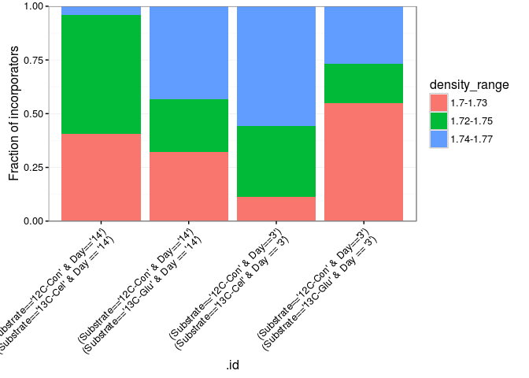

```r
# summarizing
df_l2fc_s = df_l2fc %>%
  mutate(.id = gsub(' \\| ', '\n', .id)) %>%
  filter(padj < padj_cutoff) %>%
  mutate(density_range = paste(density_min, density_max, sep='-')) %>%
  group_by(.id, sparsity_threshold, density_range) %>%
  summarize(n_incorp_OTUs = OTU %>% unique %>% length)

#plotting
ggplot(df_l2fc_s, aes(.id, n_incorp_OTUs, fill=density_range)) +
    geom_bar(stat='identity', position='fill') +
    labs(y='Fraction of incorporators') +
    scale_y_continuous(expand=c(0,0)) +
    theme_bw() +
    theme(
      axis.text.x = element_text(angle=45, hjust=1)
    )
```

Let’s look at a breakdown of incorporators for each phylum in each comparision.

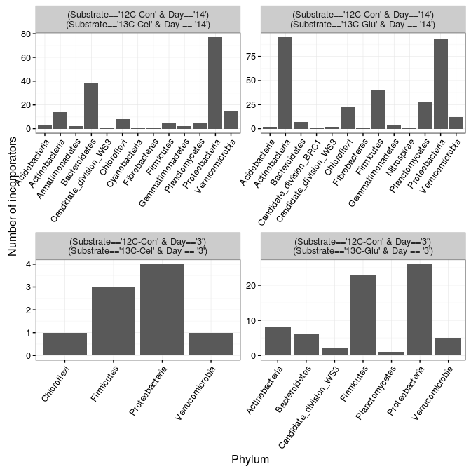

```r
# summarizing
df_l2fc_s = df_l2fc %>%
  mutate(.id = gsub(' \\| ', '\n', .id)) %>%
  filter(padj < padj_cutoff) %>%
  mutate(Rank2 = gsub('^__', '', Rank2)) %>%
  group_by(.id, Rank2) %>%
  summarize(n_incorp_OTUs = OTU %>% unique %>% length) %>%
  ungroup()

# plotting
ggplot(df_l2fc_s, aes(Rank2, n_incorp_OTUs)) +
    geom_bar(stat='identity') +
    labs(x='Phylum', y='Number of incorporators') +
    facet_wrap(~ .id, scales='free') +
    theme_bw() +
    theme(
      axis.text.x = element_text(angle=55, hjust=1)
    )
```

Note that the MW-HR-SIP method identifies more incorporators than the HR-SIP method (which uses just one BD window).

MW-HR-SIP detects more taxa for 2 main reasons. First, taxa vary in G+C content, so using only 1 BD window likely encompasses BD shifts for taxa of certain G+C contents (eg., ~50% G+C), but may miss other taxa with higher or lower G+C content. Second, taxa can vary in how much isotope was incorporated, which will affect where each taxon’s DNA is in the density gradient.